# UP

```python
import pandas as pd
import numpy as np
import seaborn as sns
import matplotlib.pyplot as plt
from sklearn.preprocessing import OneHotEncoder
import regex as re
```

```python
data = pd.read_csv("UPT.csv")
```

```python
data.head()
```

|  | Sr_no | Age | Gender | EmploymentStatus | Monthly Household Income | Household Size | Current Residential Area | Type of Residence | Current Residence Duration | Factors Influencing Residential Choice | Transportation Mode | Average Commute Time_1way | Distance traveled_1w | Average weekday trips per person | Travel Purpose | Factors influencing transportation choice |
| --- | --- | --- | --- | --- | --- | --- | --- | --- | --- | --- | --- | --- | --- | --- | --- | --- |
| 0 | 1 | 26-35 Years | Female | Student | ₹30,001 - ₹50,000 | 7 | Core | Apartment/ flat | 5-10 Years | Housing affordability , Access to public trans... | Personal Vehicle (Bike) | 10-15 minutes | 5-10 km | 4-5 trips | Education | Cost , Convenience , Availability of options, ... |
| 1 | 2 | 26-35 Years | Female | Employed Full-Time | Above ₹75,000 | 5 | Core | Row House | More than 10 years | Proximity to workplace , Housing affordability... | Personal Vehicle (Car) | 30-45 minutes | 10-15 km | 2-3 trips | Work | Cost , Travel time, Convenience , Availability... |
| 2 | 3 | 36-45 Years | Female | Employed Full-Time | Above ₹75,000 | 5 | Core | Independent House | 1-3 Years | Proximity to workplace , Housing affordability... | Personal Vehicle (Bike) | 10-15 minutes | 5-10 km | 4-5 trips | Work | Travel time, Convenience , Unavailability of P... |
| 3 | 4 | 26-35 Years | Male | Business | Above ₹75,000 | 3 | Core | Apartment/ flat | 1-3 Years | Proximity to workplace , Housing affordability... | Walking | 10-15 minutes | 1-5 km | 4-5 trips | Work | Cost , Travel time, Convenience , Availability... |
| 4 | 5 | 18-25 Years | Male | Student | ₹30,001 - ₹50,000 | 4 | Core | Apartment/ flat | 3-5 Years | Proximity to workplace , Access to public tran... | Public Transit (City Bus) | 15-30 minutes | 1-5 km | 2-3 trips | Education | Cost , Travel time, Safety |

```python
data.info()
```

```
<class 'pandas.core.frame.DataFrame'>
RangeIndex: 476 entries, 0 to 475
Data columns (total 16 columns):
 #   Column                                     Non-Null Count  Dtype
---  ------                                     --------------  -----
 0   Sr_no                                      476 non-null    int64
 1   Age                                        476 non-null    object
 2   Gender                                     476 non-null    object
 3   EmploymentStatus                           476 non-null    object
 4   Monthly Household Income                   476 non-null    object
 5   Household Size                             476 non-null    int64
 6   Current Residential Area                   476 non-null    object
 7   Type of Residence                          476 non-null    object
 8   Current Residence Duration                 476 non-null    object
 9   Factors Influencing Residential Choice     476 non-null    object
 10  Transportation Mode                        476 non-null    object
 11  Average Commute Time_1way                  476 non-null    object
 12  Distance traveled_1w                       476 non-null    object
 13  Average weekday trips per person           476 non-null    object
 14  Travel Purpose                             476 non-null    object
 15  Factors influencing transportation choice  476 non-null    object
dtypes: int64(2), object(14)
memory usage: 59.6+ KB
```

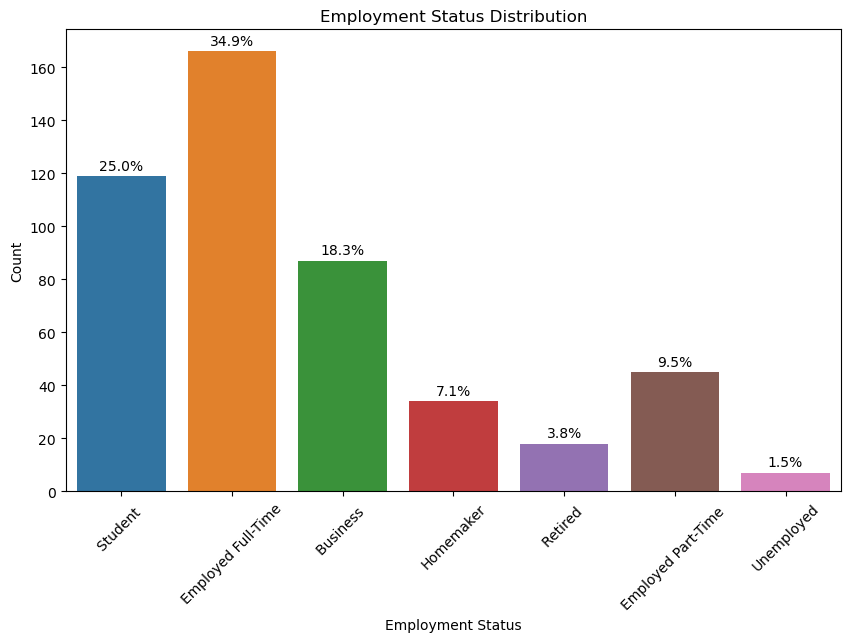

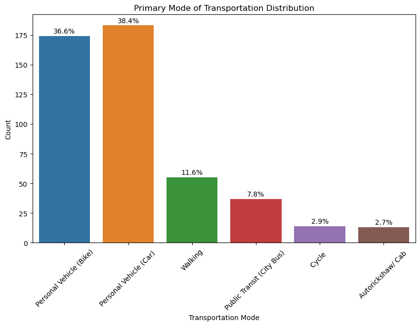

```
1    357
0    119
Name: Uses Personal Vehicle, dtype: int64
```

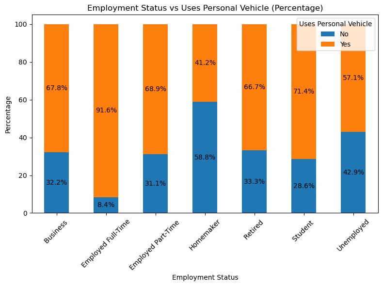

```python
pd.set_option('display.max_rows', None, 'display.max_columns', None, 'display.max_colwidth', None)

# Employment Status distribution
plt.figure(figsize=(10, 6))
ax = sns.countplot(x='EmploymentStatus', data=data)
# Calculate the total count for normalization
total = len(data['EmploymentStatus'])
# Annotate the bars with percentage
for p in ax.patches:
    percentage = '{:.1f}%'.format(100 * p.get_height() / total)
    x = p.get_x() + p.get_width() / 2
    y = p.get_height() + 0.005 * total
    ax.annotate(percentage, (x, y), ha='center')
plt.title('Employment Status Distribution')
plt.xlabel('Employment Status')
plt.ylabel('Count')
plt.xticks(rotation=45)
plt.show()

# Primary Mode of Transportation distribution
plt.figure(figsize=(10, 6))
ax = sns.countplot(x='Transportation Mode', data=data)
# Calculate the total count for normalization
total = len(data['Transportation Mode'])
# Annotate the bars with percentage
for p in ax.patches:
    percentage = '{:.1f}%'.format(100 * p.get_height() / total)
    x = p.get_x() + p.get_width() / 2
    y = p.get_height() + 0.005 * total
    ax.annotate(percentage, (x, y), ha='center')
plt.title('Primary Mode of Transportation Distribution')
plt.xlabel('Transportation Mode')
plt.ylabel('Count')
plt.xticks(rotation=45)
plt.show()

# Proposal 3
# Feature Engineering: Create a binary feature indicating if personal vehicle is the primary mode of transportation
data['Uses Personal Vehicle'] = data['Transportation Mode'].apply(lambda x: 1 if 'Personal Vehicle' in x else 0)
print(data['Uses Personal Vehicle'].value_counts())

# Calculate the count for each combination of 'EmploymentStatus' and 'Uses Personal Vehicle'
counts = data.groupby(['EmploymentStatus', 'Uses Personal Vehicle']).size().unstack()

# Calculate the percentage of each 'Uses Personal Vehicle' category within each 'EmploymentStatus'
percentages = counts.div(counts.sum(axis=1), axis=0) * 100

# Plot the stacked percentage bar chart
ax = percentages.plot(kind='bar', stacked=True, figsize=(8, 6))

# Annotate each segment with the percentage
for container in ax.containers:
    ax.bar_label(container, label_type='center', fmt='%.1f%%')

# Add title and labels
plt.title('Employment Status vs Uses Personal Vehicle (Percentage)')
plt.xlabel('Employment Status')
plt.ylabel('Percentage')
plt.xticks(rotation=45)
plt.legend(title='Uses Personal Vehicle', labels=['No', 'Yes'])

# Show the plot
plt.tight_layout()
plt.show()
```

Observations:

The “Employed Full-Time” category has the highest percentage of personal vehicle users.

Business owners, Part-Timers and Students also show a significant use of personal vehicles.

This graph is useful for understanding how employment status influences the likelihood of using a personal vehicle for transportation.

### Proposal 3: Traffic Management via Commuter Benefit Programs

Objective: Reduce personal vehicle usage. ---> Reduced Traffic Congestion

Action: To reduce the reliance on personal vehicles among full-time employees, partner with employers to offer commuter benefits such as subsidized transit passes, carpooling incentives, and flexible work schedules to reduce peak-hour traffic.

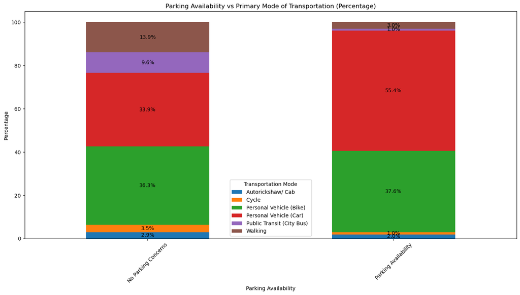

```python
# Feature Engineering: Parking Availability Analysis
data['Parking Availability'] = data['Factors influencing transportation choice'].apply(lambda x: 'Parking Availability' if 'Availability of Parking' in x else 'No Parking Concerns')

# Calculate the count for each combination of 'Parking Availability' and 'Transportation Mode'
counts = data.groupby(['Parking Availability', 'Transportation Mode']).size().unstack()

# Calculate the percentage of each 'Transportation Mode' within each 'Parking Availability'
percentages = counts.div(counts.sum(axis=1), axis=0) * 100

# Plot the stacked percentage bar chart
ax = percentages.plot(kind='bar', stacked=True, figsize=(14, 8))

# Annotate each segment with the percentage
for container in ax.containers:
    ax.bar_label(container, label_type='center', fmt='%.1f%%')

# Add title and labels
plt.title('Parking Availability vs Primary Mode of Transportation (Percentage)')
plt.xlabel('Parking Availability')
plt.ylabel('Percentage')
plt.xticks(rotation=45)
plt.legend(title='Transportation Mode')
plt.tight_layout()  # Adjust the plot to ensure everything fits without overlapping
plt.show()
```

### Proposal 4: Promote Public Transit and Non-Vehicle Modes:

The data suggests that areas with no parking concerns have a higher percentage of people using public transit and walking. Encouraging the use of these modes of transportation could alleviate parking issues.

### Proposal 5: Enhance Cycling Infrastructure:

Cycling has a low percentage in both categories, indicating potential for growth. Improving cycling lanes and facilities could encourage more people to cycle, reducing parking demand.

### Proposal 6:Implement Smart Parking Solutions:

For areas with high car usage, smart parking systems that provide real-time information on available spaces could optimize the use of existing parking.

### Proposal 7:Review Urban Planning Policies:

The high percentage of car usage in areas with parking unavailability suggests a need to review and possibly revise urban planning and zoning policies to better accommodate parking needs.

### Proposal 8:Expand Public Transit Options:

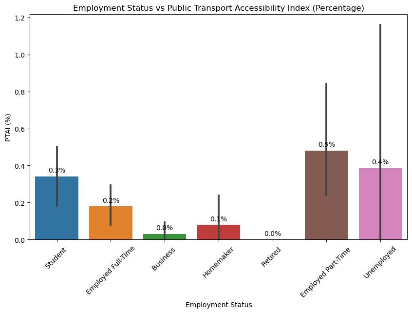

```python
# Feature Engineering: Public Transport Accessibility Index (PTAI)
data['PTAI'] = data['Transportation Mode'].apply(lambda x: 1 if 'Public Transit' in x else 0)

# Calculate the total PTAI for normalization
total_ptai = data['PTAI'].sum()

# Create a new column for PTAI percentage
data['PTAI_Percentage'] = (data['PTAI'] / total_ptai) * 100

# Plot the percentages
plt.figure(figsize=(10, 6))
bar_plot = sns.barplot(x='EmploymentStatus', y='PTAI_Percentage', data=data)

# Annotate the bars with the percentage values
for p in bar_plot.patches:
    bar_plot.annotate(format(p.get_height(), '.1f') + '%',
                      (p.get_x() + p.get_width() / 2., p.get_height()),
                      ha = 'center', va = 'center',
                      xytext = (0, 9),
                      textcoords = 'offset points')

plt.title('Employment Status vs Public Transport Accessibility Index (Percentage)')
plt.xlabel('Employment Status')
plt.ylabel('PTAI (%)')
plt.xticks(rotation=45)
plt.show()
```

The Public Transport Accessibility Index (PTAI) is a measure used to evaluate the accessibility of public transport services within a specific area. It assesses how well a location is served by public transport, considering factors such as the distance to the nearest public transport stop and the frequency of service at those stops. The PTAI can be used to inform urban planning and policy by highlighting areas with good or poor public transport accessibility, which can influence decisions on infrastructure development, service improvements, and resource allocation.

In some contexts, the PTAI is calculated using a method that considers the density of the public transport network at any location, grading each area on a scale where a score of 0 indicates very poor access to public transport, and a higher score indicates excellent access. This index is particularly useful for identifying areas that may require additional public transport services or infrastructure to improve accessibility for residents and commuters. It’s an essential tool for promoting sustainable urban mobility and ensuring equitable access to public transport.

### Proposal 9:Enhanced Service for Students:

Given that students show a higher PTAI percentage, there may be a need for more frequent or convenient public transport services around educational institutions.

### Proposal 10:Support for Part-Time Workers and the Unemployed:

The data indicates that part-time workers and unemployed individuals also rely on public transport. Proposals could focus on affordable transit options for these groups to support job searches and commuting to work.

### Proposal 11:Addressing Gaps in Service:

The low PTAI percentages for full-time employees, business owners, homemakers, and retirees suggest that public transport may not be meeting their needs. Proposals could include route expansions or schedule adjustments to better serve these populations.

### Proposal 12:Promoting Public Transport Use:

For employment categories with low PTAI, initiatives could be proposed to encourage public transport use, such as awareness campaigns or incentives.

### Proposal 13:Infrastructure Investments:

Where PTAI is low, investments in infrastructure could be proposed to improve accessibility, such as building new transit stops or improving existing ones.

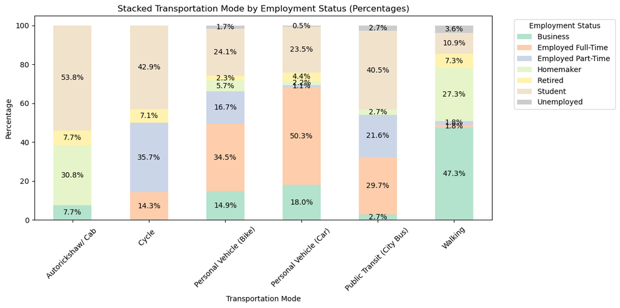

```python
# Convert columns to appropriate categorical types
categorical_columns = ['EmploymentStatus', 'Monthly Household Income', 'Household Size', 'Transportation Mode']
for col in categorical_columns:
    data[col] = pd.Categorical(data[col])

# Visualization 1: Transportation Mode by Employment Status
# First, create a pivot table with counts of each employment status for each transportation mode
pivot_data = pd.pivot_table(data, index='Transportation Mode', columns='EmploymentStatus', aggfunc='size', fill_value=0)
# Calculate the percentages
percentages = pivot_data.div(pivot_data.sum(axis=1), axis=0) * 100
# Now create the stacked bar plot
plt.figure(figsize=(12, 6))
# Plot the stacked bar graph
percentages.plot(kind='bar', stacked=True, colormap='Pastel2', figsize=(12, 6))
# Add annotations for percentages on the bars
for n, x in enumerate([*pivot_data.index.values]):
    for (proportion, y_loc) in zip(percentages.loc[x], percentages.loc[x].cumsum()):
        # Only annotate the percentage if it's greater than 0
        if proportion > 0:
            plt.text(x=n, y=(y_loc - proportion) + (proportion / 2), s=f"{proportion:.1f}%", color='black', ha='center', va='center')
plt.title('Stacked Transportation Mode by Employment Status (Percentages)')
plt.xlabel('Transportation Mode')
plt.ylabel('Percentage')
plt.xticks(rotation=45)
plt.legend(title='Employment Status', bbox_to_anchor=(1.04,1), loc="upper left")
plt.tight_layout()
plt.show()
```

#### Transportation Mode by Employment Status:

*Diversity in Transportation Choices:* The graph shows that individuals with different employment statuses have varied preferences for transportation modes. This diversity indicates that transportation planning should consider the specific needs of each employment group.

*Dominance of Personal Vehicles:* Employed full-time individuals predominantly use personal vehicles (both car and bike), suggesting that this group values the convenience and independence that personal transportation offers.

*Auto/Cycle/Walk for Students:* Students heavily rely on cab/auto, public transit (city bus) and cycle which could be due to the affordability of these modes and the likelihood of students living in campus areas or urban settings where these options are readily available.

*Retirees’ Diverse Preferences:* Retired individuals show a diverse range of transportation mode preferences, including a notable small percentage who auto,walk and cycle. This suggests that retirees may have more flexible schedules that allow for a variety of transportation choices.

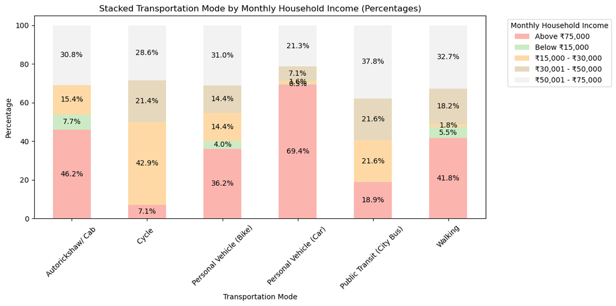

```python
# First, create a pivot table with counts of each income group for each transportation mode
pivot_data = pd.pivot_table(data, index='Transportation Mode', columns='Monthly Household Income', aggfunc='size', fill_value=0)
# Calculate the percentages
percentages = pivot_data.div(pivot_data.sum(axis=1), axis=0) * 100
# Now create the stacked bar plot
plt.figure(figsize=(12, 6))
# Plot the stacked bar graph
percentages.plot(kind='bar', stacked=True, colormap='Pastel1', figsize=(12, 6))
# Add annotations for percentages on the bars
for n, x in enumerate([*pivot_data.index.values]):
    for (proportion, y_loc) in zip(percentages.loc[x], percentages.loc[x].cumsum()):
        # Only annotate the percentage if it's greater than 0
        if proportion > 0:
            plt.text(x=n, y=(y_loc - proportion) + (proportion / 2), s=f"{proportion:.1f}%", color='black', ha='center', va='center')

plt.title('Stacked Transportation Mode by Monthly Household Income (Percentages)')
plt.xlabel('Transportation Mode')
plt.ylabel('Percentage')
plt.xticks(rotation=45)
plt.legend(title='Monthly Household Income', bbox_to_anchor=(1.04,1), loc="upper left")
plt.tight_layout()
plt.show()
```

#### Transportation Mode by Monthly Household Income:

The graph categorizes people based on their monthly income levels and shows their preferred transportation modes.

*Personal Vehicles* Significantly more popular among households earning above ₹50,000 monthly, which may reflect the financial ability to afford and maintain a car. Least used by low-income households (below ₹15,000), likely due to the higher costs associated with car ownership.

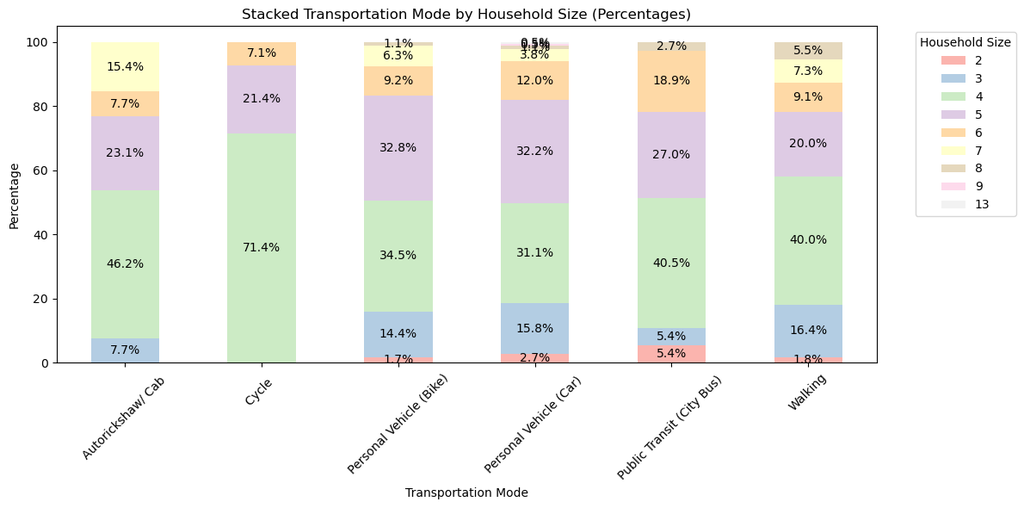

```python
# Visualization 3: Transportation Mode by Household Size
# First, create a pivot table with counts of each household size for each transportation mode
pivot_data = pd.pivot_table(data, index='Transportation Mode', columns='Household Size', aggfunc='size', fill_value=0)

# Calculate the percentages
percentages = pivot_data.div(pivot_data.sum(axis=1), axis=0) * 100

# Now create the stacked bar plot
plt.figure(figsize=(12, 6))

# Plot the stacked bar graph
percentages.plot(kind='bar', stacked=True, colormap='Pastel1', figsize=(12, 6))

# Add annotations for percentages on the bars
for n, x in enumerate([*pivot_data.index.values]):
    for (proportion, y_loc) in zip(percentages.loc[x], percentages.loc[x].cumsum()):
        # Only annotate the percentage if it's greater than 0
        if proportion > 0:
            plt.text(x=n, y=(y_loc - proportion) + (proportion / 2), s=f"{proportion:.1f}%", color='black', ha='center', va='center')

plt.title('Stacked Transportation Mode by Household Size (Percentages)')
plt.xlabel('Transportation Mode')
plt.ylabel('Percentage')
plt.xticks(rotation=45)
plt.legend(title='Household Size', bbox_to_anchor=(1.04,1), loc="upper left")
plt.tight_layout()
plt.show()
```

#### Transportation Mode by Household Size:

This graph illustrates the transportation mode choices based on the number of people in a household.

*Autorickshaw/Cab:* Medium households (4-5 members) seem to use autorickshaws/cabs more frequently. This could be due to the convenience and cost-effectiveness for fewer people. Larger households show a lower percentage, possibly because the cost becomes less feasible as the number of family members increases.

*Personal Vehicles:* Consistent usage across different household sizes, suggesting that cars/bikes are a popular personal transport option that caters to various family sizes.

*Public Transit (City Bus):* Predominantly used by smaller to medium-sized households (2-6 members), reflecting the affordability and accessibility of public transit for these groups. Decreased usage in very large households (9+ members), which could be due to the challenges of coordinating travel for many people on public transit.

###### Key Observations Across three consequetive Graphs:

Public Transit: Public transit is an essential mode of transportation, especially for lower-income individuals and those not employed full-time, emphasizing the need for reliable and efficient public transport systems.

Analyzing the three plots, which illustrate the relationship between transportation mode choices and various factors such as employment status, monthly household income, and household size, several proposals can be developed to ensure cohesive growth between residential sectors and travel behavior:

### Proposal 14:Integrated Urban Development:

Encourage mixed-use developments that combine residential, commercial, and recreational spaces. This can reduce the need for long commutes and promote the use of public transit and non-motorized transport.

### Proposal 15:Affordable Housing Near Transit Hubs:

Develop affordable housing projects near public transit hubs to make it easier for lower-income households to access reliable transportation.

### Proposal 16:Subsidized Public Transit:

Offer subsidized public transit fares for low-income individuals, students, and part-time workers to ensure equitable access to transportation.

### Proposal 17:Enhanced Public Transit Services:

Improve the frequency, reliability, and coverage of public transit services to cater to the needs of full-time employees and larger households who currently rely heavily on personal cars.

## Curated TOD Proposal

Integrated Urban Spaces: Foster high-density, mixed-use neighborhoods that blend residential, commercial, and recreational facilities within a walkable radius from transit stations.

Inclusive Housing Solutions: Establish affordable housing complexes adjacent to transit hubs, prioritizing accessibility for all income levels.

Equitable Transit Access: Implement fare subsidies for public transport to support low-income residents, students, and part-time workers.

Transit Service Excellence: Upgrade public transit frequency, reliability, and network coverage to serve the diverse needs of urban dwellers, reducing dependency on private vehicles.

```python
#Encode 'Factors Influencing Residential Choice' and 'Factors Influencing Transportation Choice'
residential_factors = data['Factors Influencing Residential Choice'].str.get_dummies(sep=', ')
transportation_factors = data['Factors influencing transportation choice'].str.get_dummies(sep=', ')
```

```python
#Combine the new binary features with the original DataFrame
data = data.join(residential_factors).join(transportation_factors)
```

```python
def convert_time_to_numerical(time_string):
    if 'less than' in time_string.lower():
        # Assuming 'Less than X minutes' means X-1
        return int(time_string.split(' ')[2]) - 1
    elif 'more than' in time_string.lower():
        # Assuming 'Less than X minutes' means X+1
        return int(time_string.split(' ')[2]) + 1
    elif 'or more' in time_string.lower():
        # Assuming 'Less than X minutes' means X+1
        return int(time_string.split(' ')[0]) + 1
    else:
        # Split the string by '-', convert to integers, and calculate the mean
        return np.mean([int(i) for i in time_string.split('-')])
```

```python
# Convert 'Average Commute Time (One Way)' and 'Distance Traveled (One Way)' to numerical
data['Average Commute Time (One Way)'] = data['Average Commute Time_1way'].apply(lambda x: convert_time_to_numerical(x.replace(' minutes', '').replace(' minute', '')))
data['Distance Traveled (One Way)'] = data['Distance traveled_1w'].apply(lambda x: convert_time_to_numerical(x.replace(' km', '').replace(' kms', '')))
data['Avg Trip'] = data['Average weekday trips per person'].apply(lambda x: convert_time_to_numerical(x.replace(' trips', '').replace(' trip', '')))
```

```python
data.info()
```

```
<class 'pandas.core.frame.DataFrame'>
RangeIndex: 476 entries, 0 to 475
Data columns (total 44 columns):
 #   Column                                        Non-Null Count  Dtype
---  ------                                        --------------  -----
 0   Sr_no                                         476 non-null    int64
 1   Age                                           476 non-null    object
 2   Gender                                        476 non-null    object
 3   EmploymentStatus                              476 non-null    category
 4   Monthly Household Income                      476 non-null    category
 5   Household Size                                476 non-null    category
 6   Current Residential Area                      476 non-null    object
 7   Type of Residence                             476 non-null    object
 8   Current Residence Duration                    476 non-null    object
 9   Factors Influencing Residential Choice        476 non-null    object
```

[output cut: 36 more lines]

```python
data = data.drop(["Sr_no", "etc.)","1","PTAI_Percentage"], axis = 1)
```

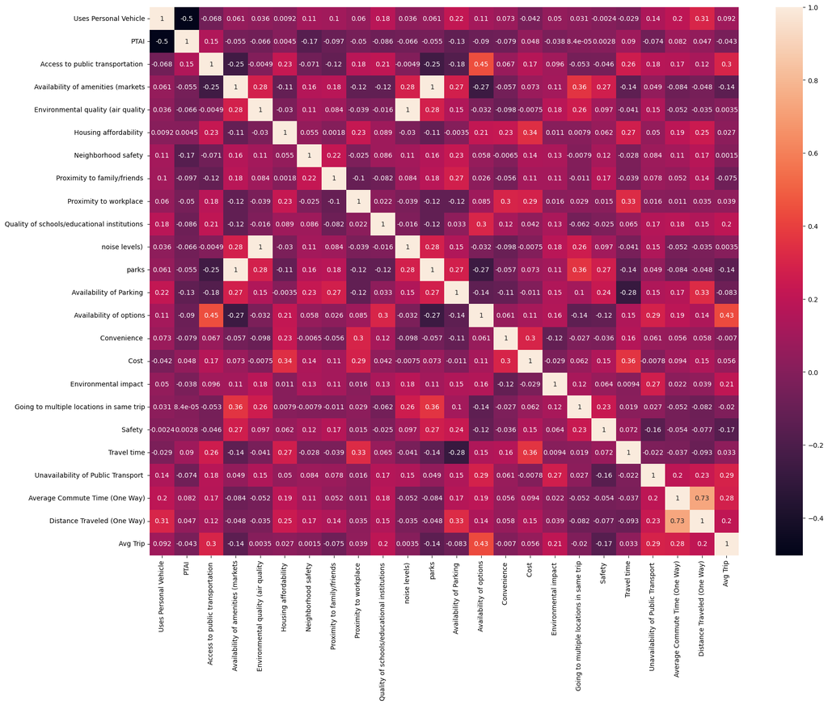

```python
#Correlation Analysis
correlation_matrix = data.corr()
plt.figure(figsize=(20, 15))
sns.heatmap(correlation_matrix, annot=True)
plt.show()
```

#### Based on the analysis of the correlation matrix heatmap, here are some insights and interpretations:

*Negative Correlation between Personal Vehicle Use and Public Transport/Alternatives:*

There is a noticeable negative correlation between the use of personal vehicles and the use of public transport or alternative transportation methods. This suggests that in areas where public transport or alternatives are readily available and convenient, people are less likely to use personal vehicles.

*Positive Correlation between Environmental Quality and Access to Amenities:*

A positive correlation between environmental quality and access to amenities indicates that neighborhoods with better air quality and environmental conditions also tend to have better access to amenities like markets, parks, and recreational facilities.

```python
data.info()
```

```
<class 'pandas.core.frame.DataFrame'>
RangeIndex: 476 entries, 0 to 475
Data columns (total 40 columns):
 #   Column                                        Non-Null Count  Dtype
---  ------                                        --------------  -----
 0   Age                                           476 non-null    object
 1   Gender                                        476 non-null    object
 2   EmploymentStatus                              476 non-null    category
 3   Monthly Household Income                      476 non-null    category
 4   Household Size                                476 non-null    category
 5   Current Residential Area                      476 non-null    object
 6   Type of Residence                             476 non-null    object
 7   Current Residence Duration                    476 non-null    object
 8   Factors Influencing Residential Choice        476 non-null    object
 9   Transportation Mode                           476 non-null    category
```

[output cut: 32 more lines]

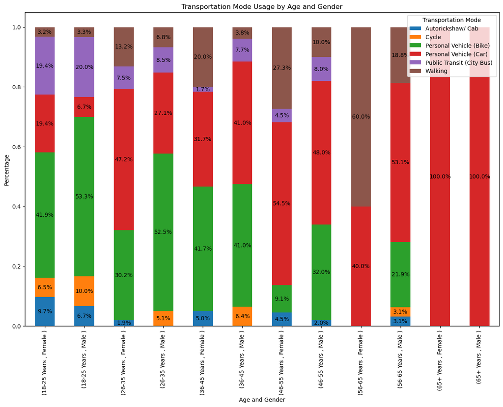

```python
# Example for creating a stacked bar chart for the 'Age' feature
import matplotlib.pyplot as plt
import pandas as pd

# Prepare the data for visualization
grouped_data = data.groupby(['Age', 'Gender', 'Transportation Mode']).size().unstack(fill_value=0)
grouped_percentage = grouped_data.div(grouped_data.sum(axis=1), axis=0)

# Plot the stacked bar chart
ax = grouped_percentage.plot(kind='bar', stacked=True, figsize=(15, 10))

# Annotate the bars with percentage values
for p in ax.patches:
    width, height = p.get_width(), p.get_height()
    if height > 0:  # Only annotate non-zero values
        x, y = p.get_xy()
        ax.text(x + width/2,
                y + height/2,
                f"{height:.1%}",
                ha='center',
                va='center')

# Add labels and title
plt.xlabel('Age and Gender')
plt.ylabel('Percentage')
plt.title('Transportation Mode Usage by Age and Gender')

# Display the legend
plt.legend(title='Transportation Mode')

# Show the plot
plt.show()
```

This chart provides a comprehensive overview of how different demographics in a population choose their mode of transportation.

### Proposals

Based on the insights derived from the study on transportation mode usage by age and gender, here are several actionable urban planning strategies that can promote cohesive growth between residential sectors and travel behavior:

Implementing these strategies can lead to a more integrated and sustainable urban environment that supports the diverse travel behaviors of its residents, promoting overall well-being and efficient use of resources.

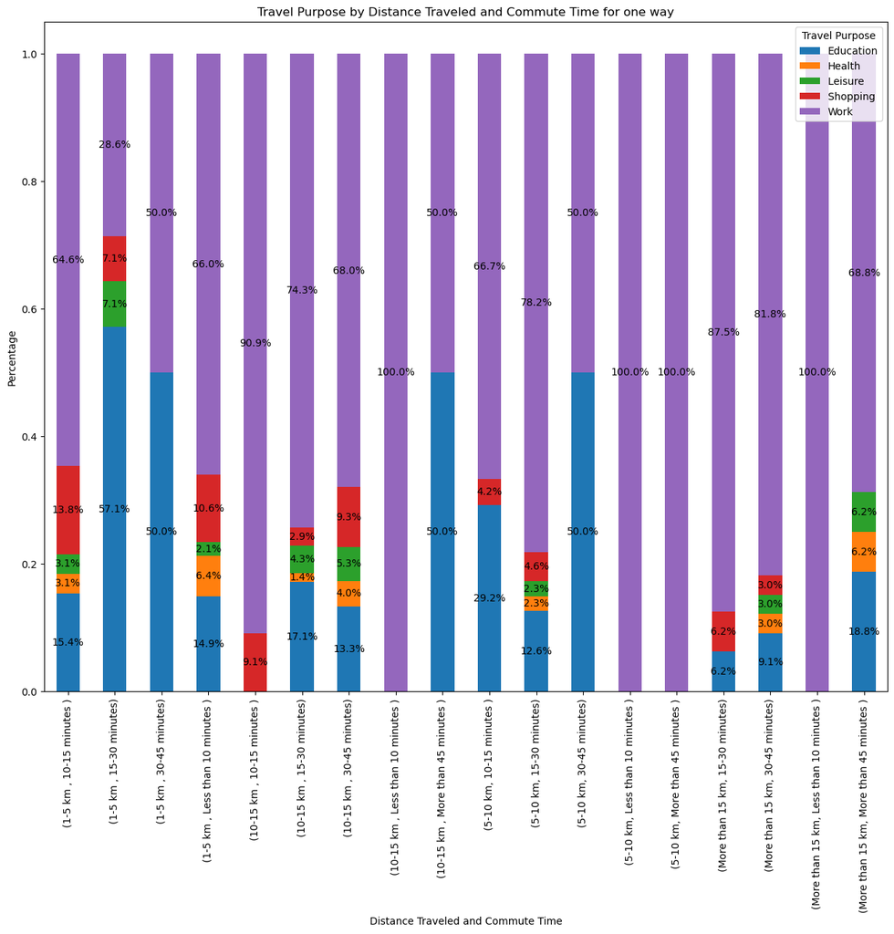

```python
# Prepare the data for visualization
grouped_data = data.groupby(['Distance traveled_1w', 'Average Commute Time_1way', 'Travel Purpose']).size().unstack(fill_value=0)
grouped_percentage = grouped_data.div(grouped_data.sum(axis=1), axis=0)

# Plot the stacked bar chart
ax = grouped_percentage.plot(kind='bar', stacked=True, figsize=(15, 12))

# Annotate the bars with percentage values
for p in ax.patches:
    width, height = p.get_width(), p.get_height()
    if height > 0:  # Only annotate non-zero values
        x, y = p.get_xy()
        ax.text(x + width/2,
                y + height/2,
                f"{height:.1%}",
                ha='center',
                va='center')

# Add labels and title
plt.xlabel('Distance Traveled and Commute Time')
plt.ylabel('Percentage')
plt.title('Travel Purpose by Distance Traveled and Commute Time for one way')

# Display the legend
plt.legend(title='Travel Purpose')

# Show the plot
plt.show()
```

### Insights:

- **Work Commute Planning**: The high percentage of work-related travel in longer commutes highlights the need for efficient transportation solutions that can reduce travel time and improve the commuting experience for workers.
- **Educational Accessibility**: The significant proportion of education-related travel in shorter commutes suggests that schools and educational institutions are generally located close to residential areas. However, there might be a need to ensure that all regions have equally accessible educational facilities.
- **Support for Local Amenities**: The prevalence of leisure and shopping trips in shorter commutes underscores the importance of having local amenities and recreational facilities within or near residential areas to support the quality of life and reduce the need for long-distance travel for these purposes.

### Relevant Proposals:

- **Enhance Public Transit**: Improve public transportation networks to support efficient travel to and from work, especially for longer commutes.
- **Develop Local Centers**: Encourage the development of local shopping and leisure centers within residential areas to reduce the necessity for long-distance travel for daily needs.
- **Accessible Healthcare Services**: Although health-related travel is less frequent, ensuring that healthcare facilities are accessible within shorter commutes can improve community health services.

## Final Proposal

To consolidate the proposals into major pointers without repetition, here's a curated summary:

**1. Neo Metro System Integration:**

- **Cost-Effective Rapid Transit:** The Neo Metro system is a cost-effective solution for rapid transit in urban areas, especially in smaller cities where ridership is lower. It can be executed at a fraction of the cost of conventional metro systems.
- **Multi-Modal Integration:** The Neo Metro corridors are planned to be complemented by existing city bus services and feeder services, creating a seamless multi-modal transport system.
- **Urban Connectivity:** By connecting key urban areas and reducing the reliance on personal vehicles, the Neo Metro system can alleviate traffic congestion and promote the use of public transport.

**2. Multi-Integrated Transit Hub:**

- **Efficient Movement:** A multi-integrated transit hub is a node that interconnects various modes of transport, such as automobiles, commuter trains, public transit, bicycles, and pedestrians, into a single convenient location.
- **Economic Development:** Such hubs can spur economic development and infrastructure growth, enhancing the quality of life in the communities they serve.
- **Community Engagement:** These hubs often become a social identity for the city, serving not just as a point of transit but also as a community node.

Incorporating these elements into the urban planning proposals can lead to:

- **Reduced Personal Vehicle Usage:** By providing efficient and cost-effective public transport options, residents are encouraged to shift from personal vehicles to public transit, reducing traffic congestion.
- **Enhanced Accessibility:** Multi-integrated transit hubs make it easier for commuters to switch between different modes of transport, improving accessibility and reducing travel times.
- **Sustainable Urban Growth:** The integration of Neo Metro systems with other transport modes supports sustainable urban development, reducing the environmental impact of transportation.

**3. Enhancing Public Transit and Non-Vehicle Modes:**

- **Expand public transit options** by increasing the frequency and routes of city buses, especially around educational institutions and employment hubs.
- **Promote public transit and walking** in areas with no parking concerns to alleviate parking issues.
- **Improve cycling infrastructure** to encourage cycling, which has potential for growth.
- **Implement smart parking solutions** in high car usage areas to optimize existing parking.
- **Review and revise urban planning policies** to accommodate parking needs and encourage mixed-use developments.

**4. Inclusive and Equitable Transit Solutions:**

- **Develop affordable housing** near transit hubs to facilitate access for lower-income households.
- **Offer subsidized public transit fares** for low-income individuals, students, and part-time workers.
- **Enhance public transit services** for full-time employees and larger households who rely on personal vehicles.
- **Address service gaps** for full-time employees, business owners, homemakers, and retirees by expanding routes or adjusting schedules.

**5. Sustainable Urban Development and Personal Vehicle Use:**

- **Foster high-density, mixed-use neighborhoods** to reduce the need for long commutes.
- **Promote car sharing and pooling services** with incentives to reduce vehicle numbers and congestion.
- **Support the transition to electric vehicles** with sufficient charging stations.

**6. Gender-Sensitive and Community-Focused Urban Design:**

- **Recognize and address gender-specific transportation needs**, ensuring safety and promoting initiatives like women's use of bicycles.
- **Engage with community members** for feedback to guide urban planning decisions.

**7. Policy and Incentives for Sustainable Transportation:**

- **Implement policies that incentivize sustainable transportation choices**, such as reduced fares, tax benefits for eco-friendly vehicles, and rewards for walking or cycling.

**8. Accessibility and Local Development:**

- **Ensure healthcare facilities** are accessible within shorter commutes.
- **Encourage local shopping and leisure centers** within residential areas to reduce long-distance travel needs.

These strategies align with the objectives of reducing traffic congestion through improved traffic management and commuter benefit programs. By focusing on the integration of Neo Metro systems, the development of multi-integrated transit hubs and other given solutions, the proposals can address the diverse needs of urban populations and promote cohesive growth between residential sectors and travel behavior.

# Impact Vision after 25 years

Implementing the proposed urban planning strategies could have significant long-term impacts over a 25-year period. Here are some potential outcomes:

*Reduced Traffic Congestion:*

By enhancing public transportation and reducing reliance on personal vehicles, traffic congestion can be significantly reduced. This would lead to shorter travel times and lower stress for commuters.

*Improved Air Quality:*

Decreased use of personal vehicles would lead to lower emissions, improving air quality. This could have a positive impact on public health, reducing respiratory and cardiovascular diseases associated with poor air quality.

*Economic Growth:*

Improved transportation infrastructure and mixed-use developments can attract businesses and stimulate local economies. This can lead to job creation and increased economic activity in the area.

*Increased Property Values:*

Neighborhoods with good public transport, amenities, and environmental quality tend to see an increase in property values. Residents in these areas could benefit from higher home values and a better quality of life.

*Social Equity:*

Making housing more affordable and improving access to quality amenities and transportation can help address social inequities. This ensures that all demographic groups have access to the benefits of urban development.

*Enhanced Public Health and Lifestyle:*

With better urban design that promotes walking and cycling, and reduced car dependency, there could be a general improvement in public health due to increased physical activity. This also contributes to a healthier lifestyle.

*Sustainability:*

Implementing environmentally friendly transportation options and urban designs can lead to more sustainable cities. This aligns with global efforts to combat climate change and promotes long-term sustainability.

*Cultural Vibrancy and Community Cohesion:*

Mixed-use developments and accessible public spaces can enhance cultural vibrancy and foster a sense of community among residents. This can improve social interactions and community bonding.

*Adaptability to Future Changes:*

A well-planned city with robust infrastructure is better equipped to adapt to future changes, whether they are technological advancements or changes in population dynamics.

*Educational Opportunities:*

Improving neighborhood safety and access to quality schools can lead to better educational outcomes for children, which can have long-term benefits for the community.

These impacts are interdependent and reinforce each other, contributing to a comprehensive improvement in urban life. The success of these strategies would depend on consistent policy implementation, community engagement, and ongoing evaluation and adjustment based on real-world outcomes.

```python
data.head()
```

[output not shown]

```python
correlation_matrix.to_csv('correlated_features.csv')
```